# statistics

*01_data_basics/08_exam/01_summary_statistics_v4*

A sample’s statistic typically approaches its corresponding population parameter, but with a small sample size there is regularly error. Let’s explore this idea with an example.

A [geometric distribution](https://en.wikipedia.org/wiki/Geometric_distribution) is a well-studied discrete population. The spinner below represents a geometric distribution with the following population parameters.
$$\mu = 8.2$$
$$\sigma = 8.69$$

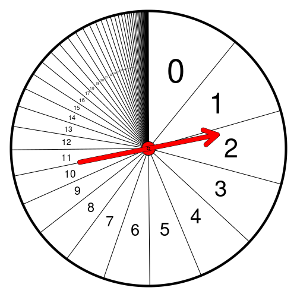

That spinner was spun many times. The raw data is displayed below and can be downloaded as a CSV.

```
0, 7, 7, 7, 10, 1, 1, 7, 6, 0, 0, 6, 8, 6, 2, 9, 4, 11, 3, 13, 6, 14, 4, 2, 9, 27, 0, 15, 2, 3, 4, 14, 3, 5, 0, 3, 9, 7, 2, 24, 4, 6, 1, 7, 15, 6, 15, 7, 1, 3, 7, 18, 9, 31, 5, 3
```

Please calculate the following sample statistics.

1. What is the sample size? (Determine $n$.)
2. What is the sample mean? (Determine $\bar{x}$. You can round to nearest hundredth.)
3. What is the **absolute difference** between the sample mean and population mean? (Calculate $|\bar{x}-\mu|$. You can round to nearest hundredth.)
4. What is the sample median?
5. What is the sample variance? (Determine $s^2$. Use Bessel’s correction. You can round to nearest hundredth.)
6. What is the sample standard deviation? (Determine $s$. Use Bessel’s correction. You can round to nearest hundredth.)
7. What is the **absolute difference** between the sample standard deviation and population standard deviation? (Calculate $|s-\sigma|$. You can round to nearest hundredth.)